# Forecast for ORP

### Time series analysis notebook

- This notebook uses the Ottawa river pathway time series; we’ll figure out how to model this and then apply a common approach to all counters.
- Ideally, we would like to find a method that can incorporate all the information we have available instead of resorting to using monthly averages.
- We might like to know when or how often the bike lanes/paths might get very busy.

#### Goals

We would like to produce a univariate time series model for each bike counter location.  
Ultimately, we can do three things with an effective time series model…  
- **smoothing**: fix data in the past that may have been erroneously measured/timed.  
- **filtering**: is the current data reasonable; is the instrument broken?  
- **forecasting**: predict traffic levels in the future from available data.

#### Bike counters data

##### *Periodicity*

The data has an obvious annual periodicity due to Ottawa’s climate; further, the ORP path has been used as a xc-skiing trail in the winter for the past couple years. We aren’t interested in the winter except for at maintenained locations, so perhaps we will just set anything after the first major snowfall as zero until early spring when counts appear normal (we can do a separate forecast for winter-maintained locations).

The weekly trend is very strong in some counters and much less so in others. ORP is not as clear as eg. Laurier/Metcalfe, where weekday traffic is much greater than the weekends. So it would be important to incorporate the annual and weekly periodicity into our forecast model.

##### *Missing data*

ORP has fairly decent looking data without anything overtly suspicious so we won’t remove any of these but might try to explain them later through special-days analysis (holidays, events), if we were attempting to explain/discard outliers. Other counters are missing data due to construction or counter malfunctions; it may be prudent to exclude these from modeling training sets. Most counters have missing data, generally in the winter; perhaps imputation of these could allow us to use other models that don’t tolerate missing values.

#### Visualizing ORP counter data

We’ll focus on the Ottawa river pathway counter (ORP) mostly to build our first model and then once we have a method that seems to fit well, we can apply it to all the counters.

##### Load tidy data

- Data I downloaded earlier and parsed into a time series data format called a *tsibble*
- Needed to fill any gaps for time series analysis with *forecast* package. (`fill_gaps()` function)

```r
bikes <- readRDS("./data/ottbike_counters.ts.RDS") %>%
  as_tibble() %>%
  mutate(weekend = ifelse(chron::is.weekend(Date), "Weekend", "Weekday"),
         weekend = fct_rev(weekend))


ORP <- bikes %>%
  filter(location == 'Ottawa River') %>%
  select(c(Date, count, weekend)) %>%
  as_tsibble(index=Date) %>%
  fill_gaps()
# str(ORP)
```

##### Time series visual summary

- First step to trying to understand the temporal and seasonal nature of the bike counters time series

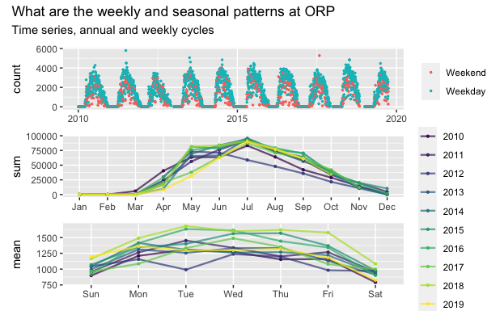

```r
a <- as.tibble(na.omit(ORP)) %>%
  ggplot(., aes(x=Date, y=count, colour=weekend)) +
  geom_point(size=0.5) +
  theme(legend.title = element_blank(),
        axis.title.x = element_blank())
        # legend.position = c(0.07,0.9))

b <- as_tibble(ORP) %>%
  mutate(month = as.factor(month(Date, label = TRUE)),
         year = as.factor(format(Date, "%Y"))) %>%
  group_by(month, year) %>%
  summarise( sum = sum(count), na.rm = TRUE) %>%
  ggplot(., aes(x = month, y = sum, color = year, group=year)) +
    geom_line(size = 0.8, alpha = 0.7) +
    geom_point(size=0.8, alpha=0.8) +
    scale_color_viridis_d(option = "D")+
    theme(legend.position = "none",
          axis.title.x = element_blank())

orp2 <- as.tibble(ORP) %>%
  mutate(wday = as.factor(wday(Date, label=TRUE)),
         month = as.factor(month(Date, label = TRUE)),
         year = format(Date, "%Y")) %>%
  group_by(year, wday) %>%
  summarise(mean = mean(count, na.rm = TRUE),
            var = var(count, na.rm = TRUE)) %>%
  ungroup()
c <- orp2 %>%  ggplot(., aes(x= wday, y=mean, group = year, colour = year)) +
    geom_line(size = 0.8, alpha = 0.7) +
    geom_point(size=0.8, alpha=0.8) +
    scale_color_viridis_d(option = "D") +
    theme(legend.position = c(1.11, 1.1),
          legend.title = element_blank(),
          axis.title.x = element_blank())

a/b/c + plot_annotation(title =  "What are the weekly and seasonal patterns at ORP",
                       subtitle = "Time series, annual and weekly cycles") &
            theme(plot.tag = element_text(size = 10))
```

This shows us the time series for ORP; we see that it has a strong annual seasonal component with peak in July and trough in Jan/Feb. The weekdays are consistently busier than weekends at this location. We can see that the data set has many low counts around or equal to zero in winter because the path becomes an x-c ski trail.

##### Create differenced count variable and visualize time series

We can plot the daily change (ie. the derivative of count or ‘differenced’ time series) to see the day-to-day variance in bike traffic.

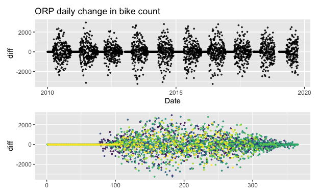

```r
ORP <- ORP %>%
  mutate(lag = lag(count,1),
         diff = count-lag)
a <- ggplot(ORP, aes(x=Date, y= diff)) +
  geom_point(size=0.6, alpha=0.8) +
  ggtitle("ORP daily change in bike count")

# b <- ggplot(ORP, aes(x= diff)) + geom_histogram(bins = 100) + ggtitle("ORP differenced counts")

b <-ORP %>%
  mutate(year = format(Date, "%Y")) %>%
  ggplot(., aes(x = yday(Date), y = diff, group = year, colour = year)) +
  geom_point(alpha = 0.8, size=0.6) +
  scale_color_viridis_d(option = "D") +
    theme(legend.position = c(1.11, 1.1),
          legend.title = element_blank(),
          axis.title.x = element_blank())
(a/b)
```

So we can see a fairly strong linear relationship between successive counts. This suggests that our model needs to incorporate this autoregression for accurate modeling.

##### Autocorrelation

Autocorrelation is correlation between observations in the time series across some lag period *k*, described by coefficient $r_k$ (same as Pearson r). Eg. for a one day lag, this would be the correlation of each count with the previous count (below).

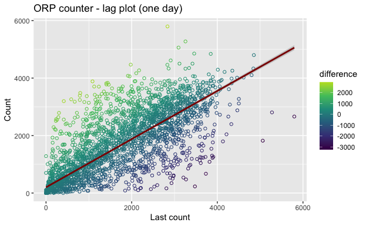

```r
c <- ggplot(ORP, aes(x=lag, y=count, colour = diff)) +
  geom_point(alpha=0.99, shape=1)+ geom_smooth(method=lm, colour='red4') +
  scale_color_viridis_c(end=0.9, "difference") +
  labs(x = "Last count", y="Count",title = "ORP counter - lag plot (one day)")
  # theme(legend.position = "none")
c
```

We can take a closer look at the autocorrelation (ACF) of bike counts at ORP by visualizing the autocorrelation coefficients for all trailing lags to find the period length of the seasonality component. We can do partial autocorrelation too, where the effect of intermediate lag days are removed.

```r
a <- ACF(ORP, .vars = count, na.action = na.pass, lag_max=42) %>%
  autoplot()
```

```
ACF currently only supports one column, `count` will be used.
```

```r
aa <- ACF(ORP, .vars = count, na.action = na.pass, lag_max=366) %>%
  autoplot() + scale_x_continuous(breaks = c(0,100,200,300))
```

```
ACF currently only supports one column, `count` will be used.
```

```r
b <- PACF(ORP, .vars = count, na.action = na.pass, lag_max=42) %>%
  autoplot()
```

```
PACF currently only supports one column, `count` will be used.
```

```r
bb <- PACF(ORP, .vars = count, na.action = na.pass, lag_max=366) %>%
  autoplot() + scale_x_continuous(breaks = c(0,100,200,300))
```

```
PACF currently only supports one column, `count` will be used.
```

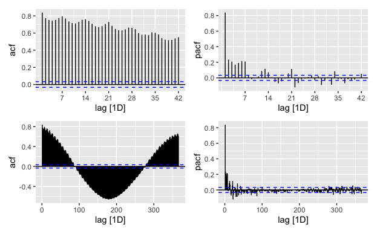

```r
(a/aa|b/bb)
```

##### Differenced time series

We can run the same analysis to see if ‘differencing’ the data (ie. taking the derivative of count). We can ascertain whether the time series is made ‘stationary’ by differencing.

Ultimately, we want to deconvolute the time series into seasonal + remainder components of the data; to do this, we need to remove any ‘trend’, which specifically refers to any longer term changes in the context of forecasting.

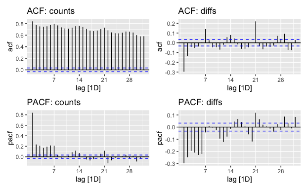

```r
## lag.max parameter doesn't work in this function??
a <- ACF(ORP, .vars = count, na.action = na.pass, lag.max=365) %>%
  autoplot() + ggtitle("ACF: counts")
b <- ACF(ORP, .vars = diff, na.action = na.pass, lag.max=365) %>%
  autoplot() + ggtitle("ACF: diffs")
c <- PACF(ORP, .vars = count, na.action = na.pass, lag.max=366) %>%
  autoplot() + ggtitle("PACF: counts")
d <- PACF(ORP, .vars = diff, na.action = na.pass, lag.max=366) %>%
  autoplot() + ggtitle("PACF: diffs")
(a + b) / (c + d)
```

Even after differencing the counts once, we still have a lot of significant autocorrelations with lags. This means we can extract more information from the seasonality of the times series, beyond just autoregression effects (seasonality effects).

What if we differenced again? (2nd derivative of count)

```r
a <- ACF(ORP, .vars = diff, na.action = na.pass, lag_max=365) %>%
  autoplot() + ggtitle("ACF diff") + scale_x_continuous(breaks=c(0,100,200,300))
```

```
ACF currently only supports one column, `diff` will be used.
```

```r
aa <- ACF(ORP, .vars = diff - lag(diff,1), na.action = na.pass, lag_max=365) %>%
  autoplot() + ggtitle("ACF diff2") + scale_x_continuous(breaks=c(0,100,200,300))
```

```
ACF currently only supports one column, `diff - lag(diff, 1)` will be used.
```

```r
b <- PACF(ORP, .vars = diff, na.action = na.pass, lag_max=366) %>%
  autoplot() + ggtitle("PACF diff")+ scale_x_continuous(breaks=c(0,100,200,300))
```

```
PACF currently only supports one column, `diff` will be used.
```

```r
bb <- PACF(ORP, .vars = diff - lag(diff,1), na.action = na.pass, lag_max=366) %>%
  autoplot() + ggtitle("PACF diff2")+ scale_x_continuous(breaks=c(0,100,200,300))
```

```
PACF currently only supports one column, `diff - lag(diff, 1)` will be used.
```

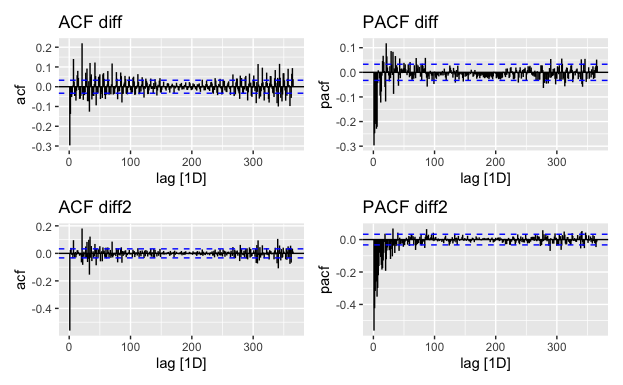

```r
a/aa|b/bb
```

##### Extracting features from ACF and PACF

ACF features

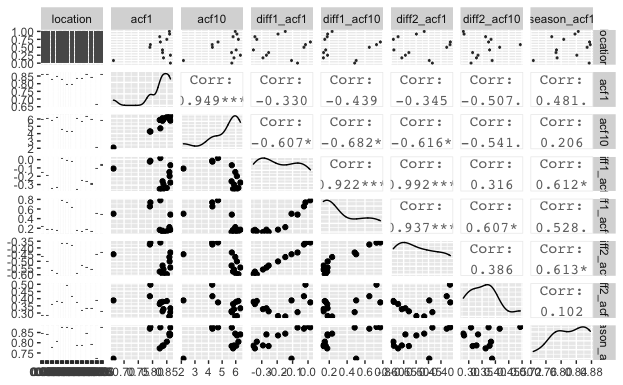

```r
bikes <- readRDS("./data/ottbike_counters.ts.RDS")
f.acf <- bikes %>% fill_gaps() %>%
  features(count, feat_acf)

GGally::ggpairs(f.acf)
```

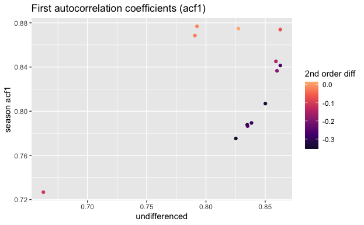

```r
ggplot(f.acf, aes(y = season_acf1, x = acf1, colour = diff1_acf1)) +
  geom_point() + geom_text_repel(aes(label=location)) +
  labs(title = "First autocorrelation coefficients (acf1)",
       x = "undifferenced", y = "season acf1", color = "2nd order diff") +
  scale_color_viridis_c(option="A", end=0.85, begin=0.1)
```

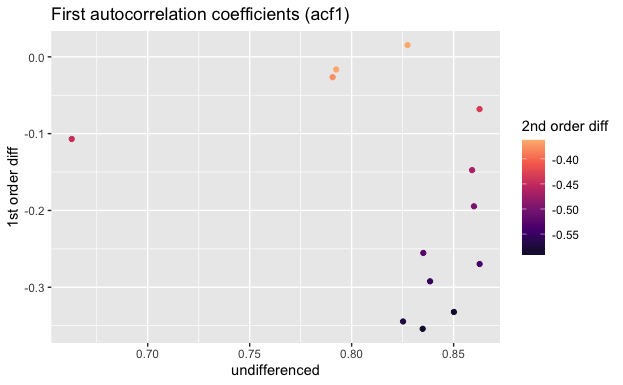

```r
ggplot(f.acf, aes(y = diff1_acf1, x = acf1, colour = diff2_acf1)) +
  geom_point() + geom_text_repel(aes(label=location)) +
  labs(title = "First autocorrelation coefficients (acf1)",
       x = "undifferenced", y = "1st order diff", color = "2nd order diff") +
  scale_color_viridis_c(option="A", end=0.85, begin=0.1)
```

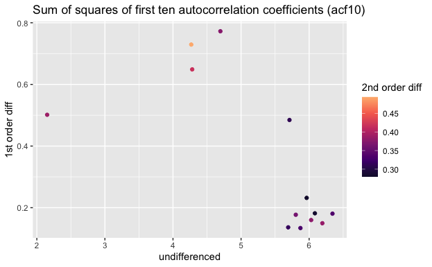

```r
ggplot(f.acf, aes(y = diff1_acf10, x = acf10, colour = diff2_acf10)) +
  geom_point() + geom_text_repel(aes(label=location)) +
  labs(title = "Sum of squares of first ten autocorrelation coefficients (acf10)",
       x = "undifferenced", y = "1st order diff", color = "2nd order diff") +
  scale_color_viridis_c(option="A", end=0.85, begin=0.1)
```

```r
# ggplot(f.acf, aes(y = acf10, x = acf1, colour = season_acf1)) + geom_point() + geom_text_repel(aes(label=location))
# ggplot(f.acf, aes(y = diff1_acf1, x = acf1, colour = diff2_acf1)) + geom_point() + geom_text_repel(aes(label=location))
```

From STL features, we can plot seasonal over trend strengths to see which series are more seasonal/trendy.  
For formulas: https://otexts.com/fpp3/stlfeatures.html

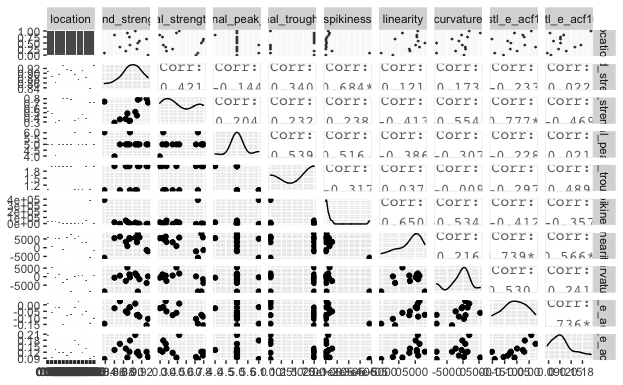

```r
library(ggrepel)
f.stl <- bikes %>%
  features(count, feat_stl)

GGally::ggpairs(f.stl)
```

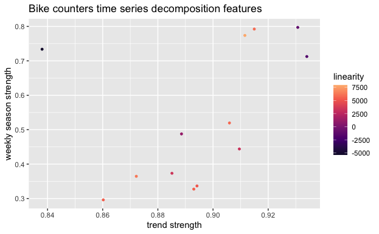

```r
ggplot(f.stl, aes(x=trend_strength, y=seasonal_strength_week, color= linearity)) + geom_point(size=1) +
  geom_text_repel(aes(label=location)) +
  scale_color_viridis_c(option="A", end=0.85, begin=0.1) +
  labs(title= "Bike counters time series decomposition features",
       x = "trend strength", y= "weekly season strength")
```

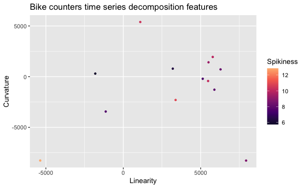

```r
ggplot(f.stl, aes(x=linearity, y=curvature, color= log(spikiness))) +
  geom_point(size=1) +
  geom_text_repel(aes(label=location)) +
  scale_color_viridis_c(option="A", end=0.85, begin=0.1) +
  labs(title= "Bike counters time series decomposition features",
       x = "Linearity", y= "Curvature", color = 'Spikiness')
```

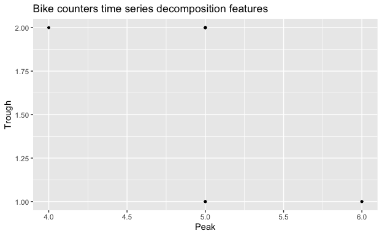

```r
ggplot(f.stl, aes(x=seasonal_peak_week, y=seasonal_trough_week)) +
  geom_point(size=1) +
  geom_text_repel(aes(label=location)) +
  labs(title= "Bike counters time series decomposition features",
       x = "Peak", y= "Trough")
```

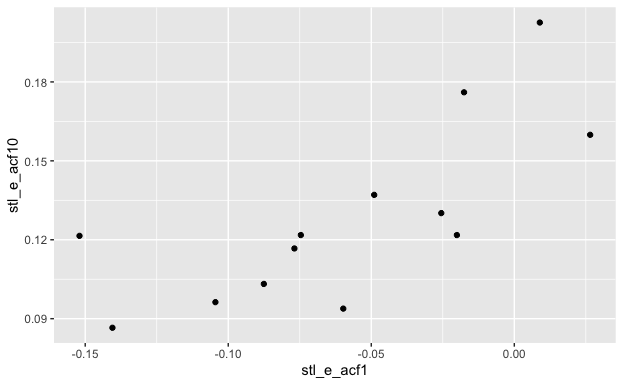

```r
ggplot(f.stl, aes(x = stl_e_acf1, y = stl_e_acf10)) + geom_point() + geom_text_repel(aes(label=location))
```

STL gives other statistics about each time series: linearity, curvature, spikiness

- spikiness measures the prevalence of spikes in the remainder component $R_t$ of the STL decomposition. It is the variance of the leave-one-out variances of $R_t$
- linearity measures the linearity of the trend component of the STL decomposition. It is based on the coefficient of a linear regression applied to the trend component.
- curvature measures the curvature of the trend component of the STL decomposition. It is based on the coefficient from an orthogonal quadratic regression applied to the trend component.

We can see which days of the week are the peak or trough days of the weekly cycle. This tells us about the weekly seasonality at each counter.

We can also get the acf1 and acf10 for the remainder component of the time series:

- stl_e_acf1 is the first autocorrelation coefficient of the remainder series.
- stl_e_acf10 is the sum of squares of the first ten autocorrelation coefficients of the remainder series.

#### PCA of all time series features available

```r
library(broom)
library(ggrepel)

bikes_features <- bikes %>%
  filter(location != 'Portage') %>%
  features(count, feature_set(pkgs='feasts'))
```

[output not shown]

```r
# remove all columns with NA's?
pcs <- bikes_features %>%
  select(-c(1)) %>%
  select_if(~ !any(is.na(.))) %>%
  mutate_if(is.integer, as.numeric) %>%
  select(-as.numeric(which(apply(bikes_features, 2, var)==0))) %>%
  select(-c(pp_pvalue, bp_pvalue)) %>%
  prcomp(scale=TRUE, na.action = na.pass) %>%
  augment(bikes_features)
```

```
NAs introduced by coercionIn prcomp.default(., scale = TRUE, na.action = na.pass) :
 extra argument ‘na.action’ will be disregarded
```

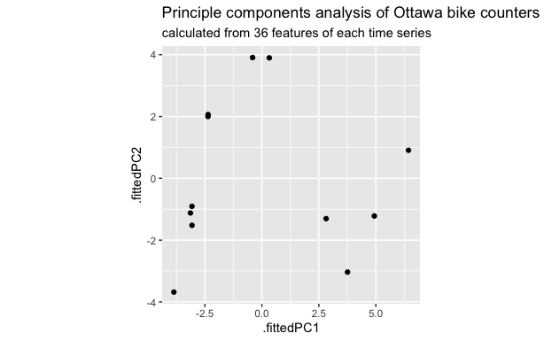

```r
pcs %>%
  ggplot(aes(x=.fittedPC1, y=.fittedPC2)) +
  geom_point() +
  geom_text_repel(aes(label=location)) +
  theme(aspect.ratio=1) +
  labs(title= "Principle components analysis of Ottawa bike counters",
       subtitle = "calculated from 36 features of each time series ")
```

```r
saveRDS(pcs, "./data/bikes_pca.RDS")
```

### Decomposition

Comparing STL decomposition with default parameters with and without ‘robust’ setting for handling outliers

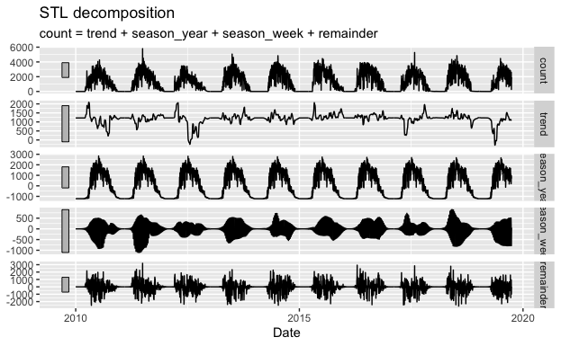

```r
###

orp <- ORP[, c(1,2)] %>%
  filter(!is.na(count)) %>%
  fill_gaps() %>%
  mutate(count = na.interp(count, lambda = 'auto')) %>% as_tsibble()
orp %>% model(STL(count ~ season(window=13), robust=TRUE)) %>%
  components() %>% autoplot()
```

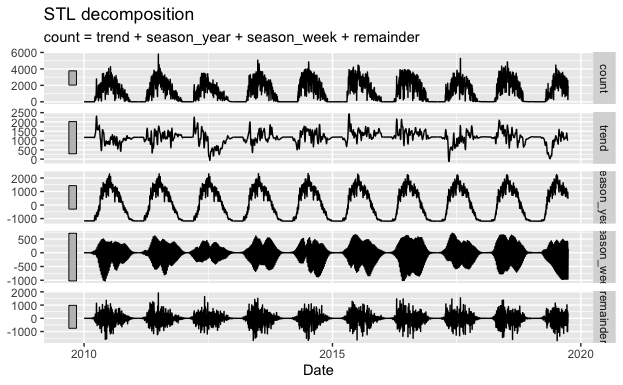

```r
orp %>% model(STL(count ~ season(window=13), robust=FALSE)) %>%
  components() %>% autoplot()
```

The STL algorithm decomposed our sequence automatically to a weekly and annual seasonal model: count ~ trend + year + week + remainder.

### interpolation / imputation

There are some periods with missing values within the time series (below) that we should interpolate such that modeling will perform better and more methods will be available.

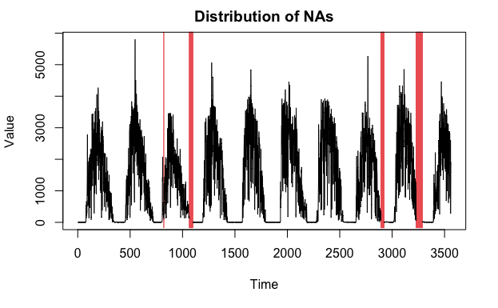

```r
library(imputeTS)
plotNA.distribution(ORP$count, cexPoints = 0)
```

The `imputeTS` ppackage has interpolation (linear, spline, ‘stinterp’) and Kalman smoothing algorithms to fill missing values. The Kalman filter can be a structural model fitted by maximum likelihood; this would seem to suit our data better than a linear fit.

The overall difference is pretty minor; this shouldn’t really influence the model too much. The Kalman filter tends to give larger imputed values than the interpolation; perhaps this is because it is taking seasonality into account. We’ll use this imputed time series for modeling.

```r
# make ORP into base R time series
orp.ts <- ts(ORP[, c(2)], start = c(2010,1,1), deltat = 1/365)
orp.diff <- diff(orp.ts)
# str(orp.ts)

orp.ts2 <- ORP %>%
  mutate(count = na_interpolation(count, option = "stine"))
orp.ts3 <- ORP %>%
  mutate(count = na_kalman(count))
tt <- theme(axis.title.x = element_blank(),
            axis.text.x = element_blank())
a <- autoplot(orp.ts) + ggtitle("Raw, interpolated, Kalman smoothing") +tt
b <- autoplot(orp.ts2) + tt
```

```
Plot variable not specified, automatically selected `.vars = count`
```

```r
c <- autoplot(orp.ts3)
```

```
Plot variable not specified, automatically selected `.vars = count`
```

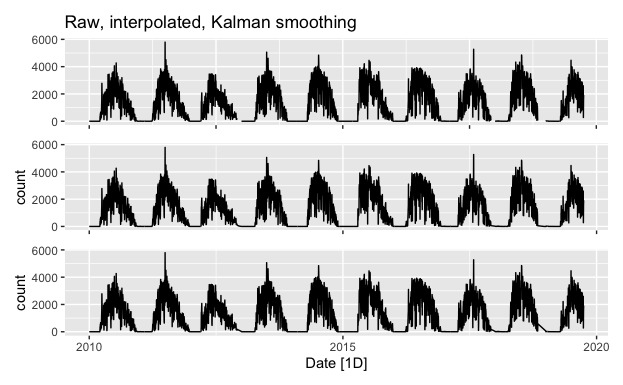

```r
a/b/c
```

```r
orp.ts <- ts(orp.ts3[, c(2)], start = c(2010,1,1), deltat = 1/365)
orp.diff <- diff(orp.ts)
```

## Some basic time-series models

We now have a pretty good idea of the bike traffic patterns at ORP and the contributions of seasonal components and randomness, while the overall trend isn’t very strong in comparison.

##### **Linear trend model**

Model: expected value is the mean value for entire time series.

- RMSE = 1226

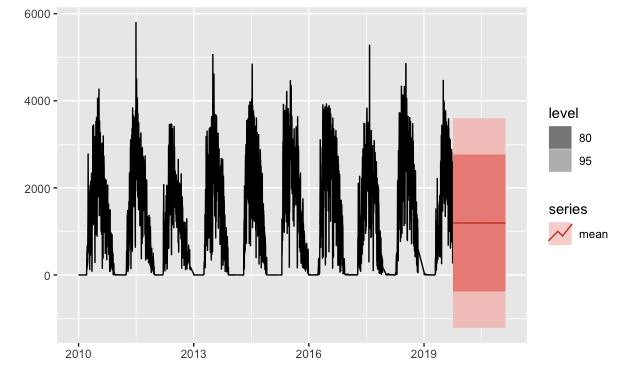

```r
# orp.ts <- window(orp.ts, start = 2011, end =c(2019,8))
fit.mean <- meanf(orp.ts, h=500)
autoplot(orp.ts) +
  autolayer(fit.mean, series = 'mean')
```

```r
summary(fit.mean)
```

```
Forecast method: Mean

Model Information:
$mu
[1] 1193.564

$mu.se
[1] 20.56121

$sd
[1] 1226.799

$bootstrap
[1] FALSE

$call
meanf(y = orp.ts, h = 500)

attr(,"class")
[1] "meanf"

Error measures:
                       ME     RMSE      MAE  MPE MAPE     MASE      ACF1
Training set 2.289654e-14 1226.627 1075.433 -Inf  Inf 1.898992 0.8420836

Forecasts:
```

|  | Point Forecast | Lo 80 | Hi 80 | Lo 95 | Hi 95 |
| --- | --- | --- | --- | --- | --- |
| 2019.7534 | 1193.564 | -379.1559 | 2766.283 | -1212.075 | 3599.202 |
| 2019.7562 | 1193.564 | -379.1559 | 2766.283 | -1212.075 | 3599.202 |
| 2019.7589 | 1193.564 | -379.1559 | 2766.283 | -1212.075 | 3599.202 |
| 2019.7616 | 1193.564 | -379.1559 | 2766.283 | -1212.075 | 3599.202 |
| 2019.7644 | 1193.564 | -379.1559 | 2766.283 | -1212.075 | 3599.202 |
| 2019.7671 | 1193.564 | -379.1559 | 2766.283 | -1212.075 | 3599.202 |
| 2019.7699 | 1193.564 | -379.1559 | 2766.283 | -1212.075 | 3599.202 |
| 2019.7726 | 1193.564 | -379.1559 | 2766.283 | -1212.075 | 3599.202 |
| 2019.7753 | 1193.564 | -379.1559 | 2766.283 | -1212.075 | 3599.202 |
| 2019.7781 | 1193.564 | -379.1559 | 2766.283 | -1212.075 | 3599.202 |

[output cut: 490 more lines]

```
    Ljung-Box test

data:  Residuals from Mean
Q* = 569978, df = 711, p-value < 2.2e-16

Model df: 1.   Total lags used: 712
```

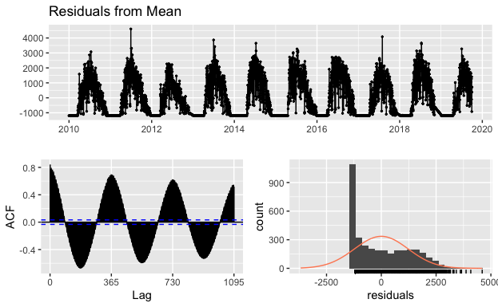

```r
checkresiduals(fit.mean)
```

##### **naive model**

Naive model: Expected value is same as previous value. Obviously, doesn’t forecast very well because of strong seasonality of data.

- RMSE = 689

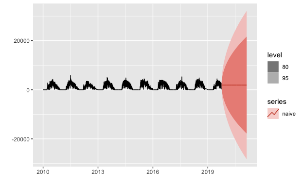

```r
fit.naive <- naive(orp.ts, h=500)
autoplot(orp.ts) +
  autolayer(fit.naive, series = 'naive')
```

```r
summary(fit.naive)
```

```
Forecast method: Naive method

Model Information:
Call: naive(y = orp.ts, h = 500)

Residual sd: 689.149

Error measures:
                    ME     RMSE      MAE  MPE MAPE      MASE       ACF1
Training set 0.5383535 689.0523 407.2719 -Inf  Inf 0.7191576 -0.2923796

Forecasts:
```

|  | Point Forecast | Lo 80 | Hi 80 | Lo 95 | Hi 95 |
| --- | --- | --- | --- | --- | --- |
| 2019.7534 | 1916 | 1032.94390 | 2799.056 | 565.482236 | 3266.518 |
| 2019.7562 | 1916 | 667.17008 | 3164.830 | 6.079461 | 3825.921 |
| 2019.7589 | 1916 | 386.50197 | 3445.498 | -423.165385 | 4255.165 |
| 2019.7616 | 1916 | 149.88780 | 3682.112 | -785.035529 | 4617.036 |
| 2019.7644 | 1916 | -58.57347 | 3890.573 | -1103.849526 | 4935.850 |
| 2019.7671 | 1916 | -247.03686 | 4079.037 | -1392.079412 | 5224.079 |
| 2019.7699 | 1916 | -420.34684 | 4252.347 | -1657.134146 | 5489.134 |
| 2019.7726 | 1916 | -581.65983 | 4413.660 | -1903.841078 | 5735.841 |
| 2019.7753 | 1916 | -733.16830 | 4565.168 | -2135.553293 | 5967.553 |
| 2019.7781 | 1916 | -876.46858 | 4708.469 | -2354.712156 | 6186.712 |

[output cut: 490 more lines]

```
    Ljung-Box test

data:  Residuals from Naive method
Q* = 3437.5, df = 712, p-value < 2.2e-16

Model df: 0.   Total lags used: 712
```

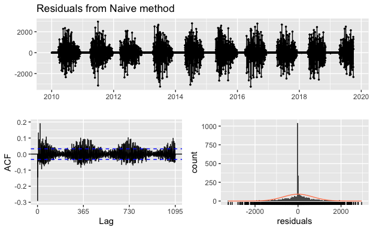

```r
checkresiduals(fit.naive)
```

##### **seasonal naive model benchmark**

Seasonal naive: Captures seasonality and error gets progressively larger as forecast moves further from data. Model each forecast to be equal to the last observed value from the same season of the year. Would need to check to make sure the days of week line up with calendar? Week is strongly seasonal. RMSE = 882 (Residual sd)

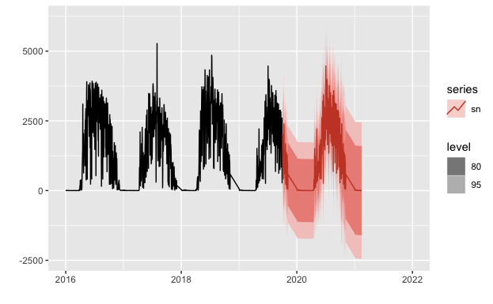

```r
fit.sn <- snaive(orp.ts, h= 500)
autoplot(orp.ts) +
  autolayer(fit.sn, series = 'sn') +
  xlim(c(2016, 2022))
```

```r
summary(fit.sn)
```

```
Forecast method: Seasonal naive method

Model Information:
Call: snaive(y = orp.ts, h = 500)

Residual sd: 882.6652

Error measures:
                    ME     RMSE      MAE  MPE MAPE MASE      ACF1
Training set -6.583687 882.5516 566.3181 -Inf  Inf    1 0.4080006

Forecasts:
```

|  | Point Forecast | Lo 80 | Hi 80 | Lo 95 | Hi 95 |
| --- | --- | --- | --- | --- | --- |
| 2019.7534 | 2026.00000 | 894.964552 | 3157.035 | 296.23055 | 3755.769 |
| 2019.7562 | 816.00000 | -315.035448 | 1947.035 | -913.76945 | 2545.769 |
| 2019.7589 | 1979.00000 | 847.964552 | 3110.035 | 249.23055 | 3708.769 |
| 2019.7616 | 1410.00000 | 278.964552 | 2541.035 | -319.76945 | 3139.769 |
| 2019.7644 | 1640.00000 | 508.964552 | 2771.035 | -89.76945 | 3369.769 |
| 2019.7671 | 417.00000 | -714.035448 | 1548.035 | -1312.76945 | 2146.769 |
| 2019.7699 | 601.00000 | -530.035448 | 1732.035 | -1128.76945 | 2330.769 |
| 2019.7726 | 457.00000 | -674.035448 | 1588.035 | -1272.76945 | 2186.769 |
| 2019.7753 | 2397.00000 | 1265.964552 | 3528.035 | 667.23055 | 4126.769 |
| 2019.7781 | 2264.00000 | 1132.964552 | 3395.035 | 534.23055 | 3993.769 |

[output cut: 490 more lines]

```
    Ljung-Box test

data:  Residuals from Seasonal naive method
Q* = 7607.2, df = 712, p-value < 2.2e-16

Model df: 0.   Total lags used: 712
```

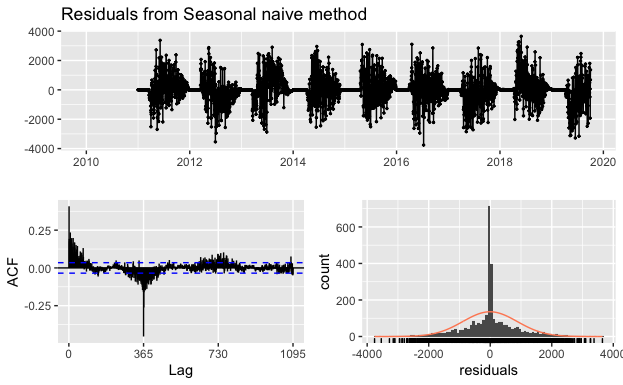

```r
checkresiduals(fit.sn)
```

##### seasonal naive with differenced data

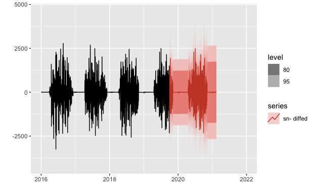

```r
fit.d <- snaive(orp.diff, h=500)
autoplot(orp.diff) +
  autolayer(fit.d, series = 'sn- diffed') +
  xlim(c(2016, 2022))
```

```r
summary(fit.d)
```

```
Forecast method: Seasonal naive method

Model Information:
Call: snaive(y = orp.diff, h = 500)

Residual sd: 960.2872

Error measures:
                    ME     RMSE      MAE MPE MAPE MASE       ACF1
Training set 0.4257984 960.1369 590.2764 NaN  Inf    1 -0.3176913

Forecasts:
```

|  | Point Forecast | Lo 80 | Hi 80 | Lo 95 | Hi 95 |
| --- | --- | --- | --- | --- | --- |
| 2019.7534 | 1474.000000 | 243.535028 | 2704.464972 | -407.83378 | 3355.83378 |
| 2019.7562 | -1210.000000 | -2440.464972 | 20.464972 | -3091.83378 | 671.83378 |
| 2019.7589 | 1163.000000 | -67.464972 | 2393.464972 | -718.83378 | 3044.83378 |
| 2019.7616 | -569.000000 | -1799.464972 | 661.464972 | -2450.83378 | 1312.83378 |
| 2019.7644 | 230.000000 | -1000.464972 | 1460.464972 | -1651.83378 | 2111.83378 |
| 2019.7671 | -1223.000000 | -2453.464972 | 7.464972 | -3104.83378 | 658.83378 |
| 2019.7699 | 184.000000 | -1046.464972 | 1414.464972 | -1697.83378 | 2065.83378 |
| 2019.7726 | -144.000000 | -1374.464972 | 1086.464972 | -2025.83378 | 1737.83378 |
| 2019.7753 | 1940.000000 | 709.535028 | 3170.464972 | 58.16622 | 3821.83378 |
| 2019.7781 | -133.000000 | -1363.464972 | 1097.464972 | -2014.83378 | 1748.83378 |

[output cut: 490 more lines]

```
    Ljung-Box test

data:  Residuals from Seasonal naive method
Q* = 2972.3, df = 712, p-value < 2.2e-16

Model df: 0.   Total lags used: 712
```

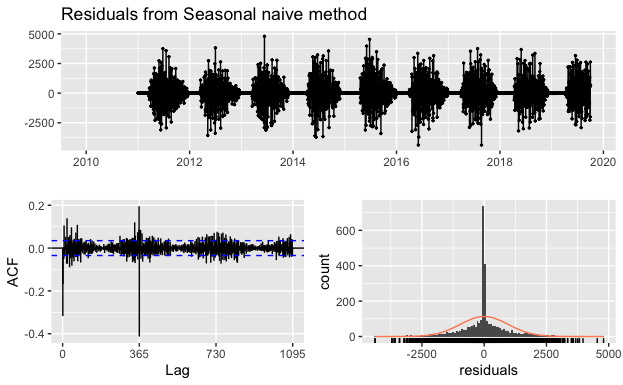

```r
checkresiduals(fit.d)
```

##### Random walk with drift model.

The same as the naive method except with drift according to the mean rate of change over time. The amount of drift is tiny so it appears the same as the naive model with similar fit. RMSE = 689

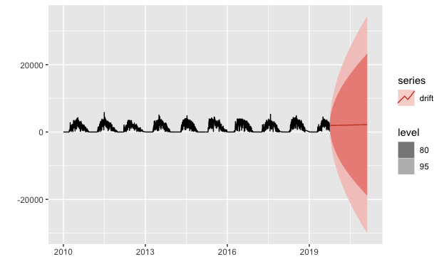

```r
fit.drift <- rwf(orp.ts, drift = TRUE, h=500)
autoplot(orp.ts) +
  autolayer(fit.drift, series = 'drift')
```

```r
summary(fit.drift)
```

```
Forecast method: Random walk with drift

Model Information:
Call: rwf(y = orp.ts, h = 500, drift = TRUE)

Drift: 0.5384  (se 11.5518)
Residual sd: 689.149

Error measures:
                      ME     RMSE      MAE  MPE MAPE      MASE       ACF1
Training set -1.7585e-14 689.0521 407.3656 -Inf  Inf 0.7193229 -0.2923796

Forecasts:
```

|  | Point Forecast | Lo 80 | Hi 80 | Lo 95 | Hi 95 |
| --- | --- | --- | --- | --- | --- |
| 2019.7534 | 1916.538 | 1033.35844 | 2799.718 | 565.831228 | 3267.245 |
| 2019.7562 | 1917.077 | 667.89623 | 3166.257 | 6.620031 | 3827.533 |
| 2019.7589 | 1917.615 | 387.47282 | 3447.757 | -422.535560 | 4257.766 |
| 2019.7616 | 1918.153 | 151.04927 | 3685.258 | -784.399152 | 4620.706 |
| 2019.7644 | 1918.692 | -57.26803 | 3894.652 | -1103.277964 | 4940.661 |
| 2019.7671 | 1919.230 | -245.62912 | 4084.089 | -1391.636380 | 5230.097 |
| 2019.7699 | 1919.768 | -418.87478 | 4258.412 | -1656.877740 | 5496.415 |
| 2019.7726 | 1920.307 | -580.15860 | 4420.772 | -1903.825040 | 5744.439 |
| 2019.7753 | 1920.845 | -731.67075 | 4573.361 | -2135.827862 | 5977.518 |
| 2019.7781 | 1921.384 | -875.00565 | 4717.773 | -2355.324668 | 6198.092 |

[output cut: 490 more lines]

```
    Ljung-Box test

data:  Residuals from Random walk with drift
Q* = 3437.5, df = 711, p-value < 2.2e-16

Model df: 1.   Total lags used: 712
```

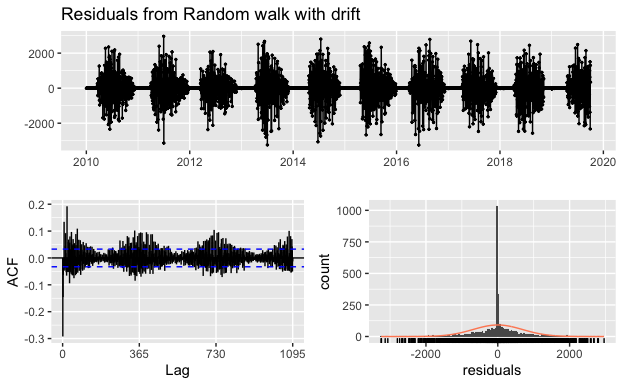

```r
checkresiduals(fit.drift)
```

#### All the simple models

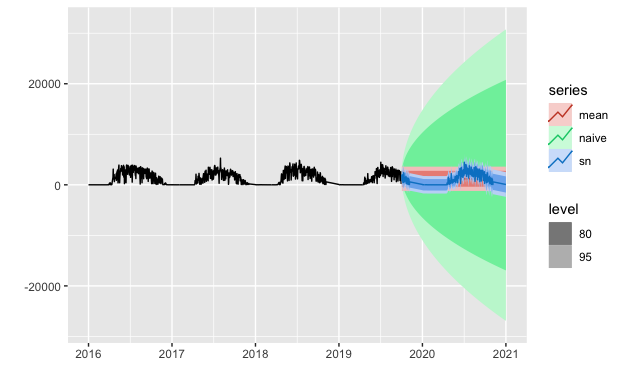

```r
autoplot(orp.ts) +
    # autolayer(fit.drift, series = 'drift') +
    autolayer(fit.naive, series = 'naive') +
    autolayer(fit.mean, series = 'mean') +
    autolayer(fit.sn, series = 'sn')  +
  xlim(c(2016, 2021))
```

```r
    # autolayer(fit.d, series = 'sn- diffed') +
```